# Module 4 Pair Quiz

Raphael Lee, Javier Bolong

7/30/2021

## *Question 1*

An article in the Journal of Sound and Vibration [“Measurement of Noise-Evoked Blood Pressure by Means of Averaging Method: Relation between Blood Pressure Rise and PSL” (1991, Vol. 151(3), pp. 383-394)] described a study investigating the relationship between noise exposure and hypertension. The following data are representative of those reported in the article.

# **A**

a) Draw a scatter diagram of y (blood pressure rise in millimeters of mercury) versus x (sound pressure level in decibels). Does a simple linear regression model seem reasonable in this situation?

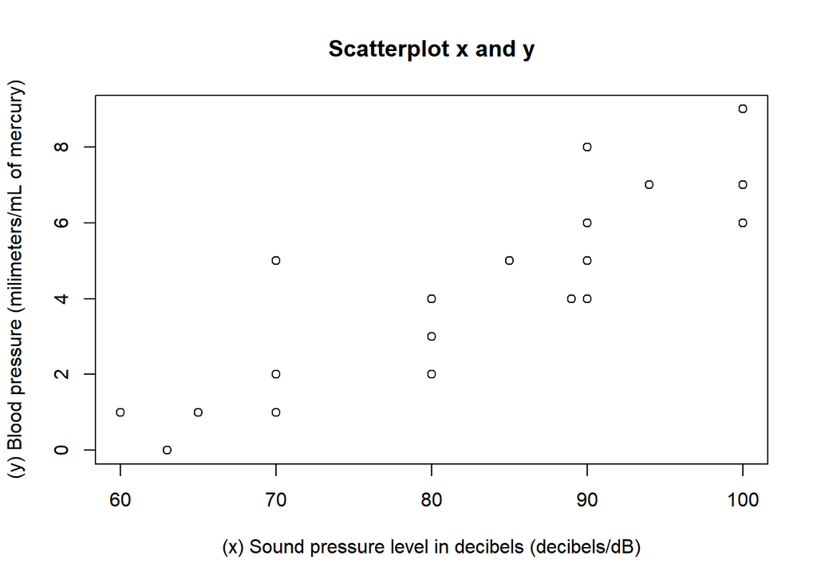

```
## [1] 0.1742939
```

```
## [1] -10.13154
```

```
##
## Call:
## lm(formula = y ~ x)
##
## Coefficients:
## (Intercept)            x
##    -10.1315       0.1743
```

$$\widehat{y} = 0.1742939(x) + (-10.1315377)$$

```r
# solving for set_residuals
set_y_hats <- (m * x) + intercept
```

Then using this equation, using each x-value in the set, we get a y hat value. The code above was used to do that

```r
set_residuals <- y -set_y_hats
set_residuals
```

```
##  [1]  0.67390167 -0.84898013 -0.19756799 -0.06903766  2.93096234 -1.06903766
##  [7]  0.18802301  0.44508368 -1.81197699 -0.81197699  0.31655335 -1.38062238
## [13]  0.44508368  2.44508368 -1.55491632 -0.55491632  0.74790795  1.70214435
## [19] -0.29785565 -1.29785565
```

```r
shapiro.test(set_residuals)
```

```
##
##  Shapiro-Wilk normality test
##
## data:  set_residuals
## W = 0.94137, p-value = 0.2545
```

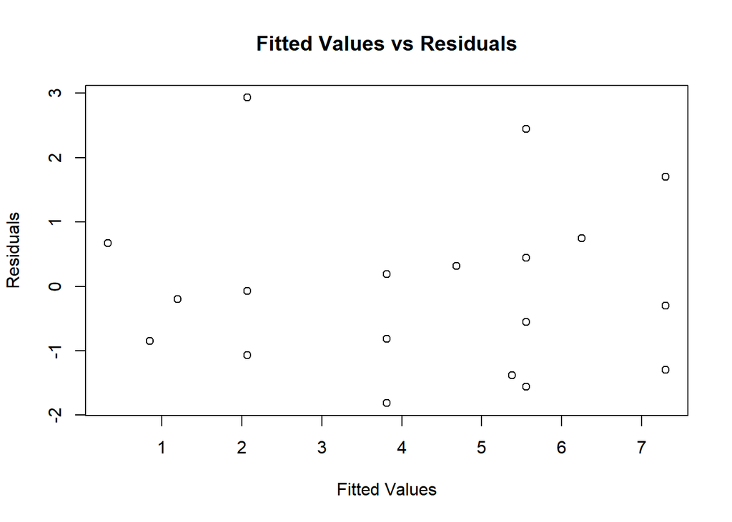

```r
plot(set_y_hats, set_residuals, main = "Fitted Values vs Residuals", xlab = "Fitted Values", ylab = "Residuals")
```

Then the set of residuals was made using the code above and a scatter plot. Using the Shapiro Wilk test, the set of residuals is normally distributed since the the p-value is more than 0.05. Based of the scatter plot of fitted values and residuals, the points are random variables due to its random spread of the graph. The variance is constant since there is a regular thickness in terms of spread as we move left to right. Thus a simple linear regression model is appropriate. Another test can be done using the coefficient of Determination.

```r
k_determination <- (cor(x, y)^2)

k_determination
```

```
## [1] 0.748257
```

The above code was used to find the correlation coefficient. Since squaring that will give the coefficient of determination, the above code was used.

$$R^2 = 1 - \frac{SS_E}{SS_T} = 0.748257$$

Since the number above is in between 0 and 1 and the value is relatively high, which indicates a strong ability to predict outcomes, we can also conclude that a simple linear regression model can be used.

Answer: Simple linear regression model is suitable for the given situation.

# **B**

b) Fit the simple linear regression model using least squares. Find an estimate of σ2.

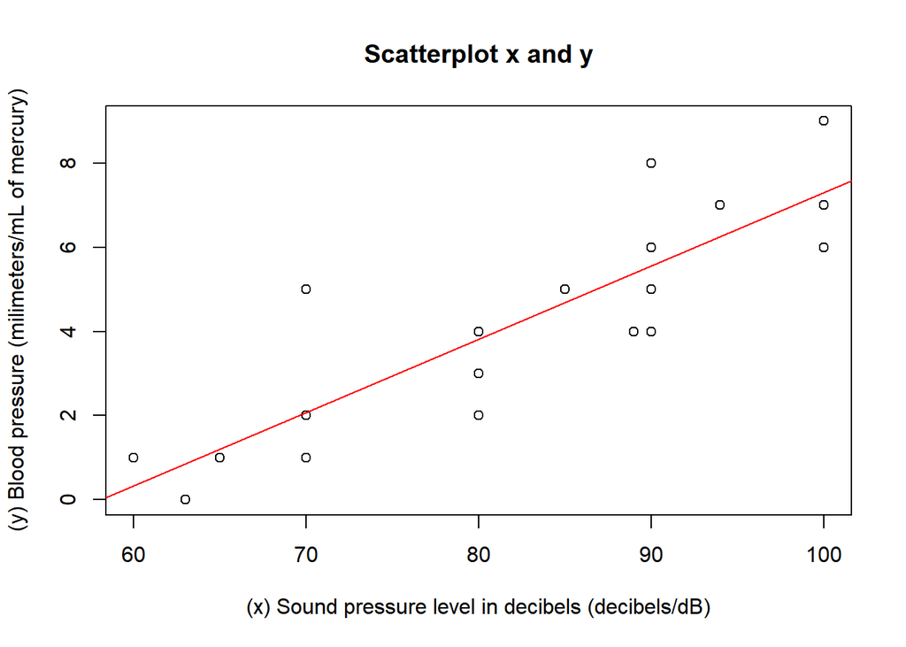

```r
plot(x, y, main = "Scatterplot x and y", xlab = "(x) Sound pressure level in decibels (decibels/dB)", ylab = "(y) Blood pressure (milimeters/mL of mercury)")
abline(lm(y~x), col = "red")
```

The above code was used to plot a simple linear regression model. With the function lm, the line was plotted for the scatter plot.

```r
estimator <- (sum((y - set_y_hats) ^ 2)) / (n - 2)
estimator
```

```
## [1] 1.737026
```

The above code was used to find the unbiased estimator.

# **C**

c) Find the predicted mean rise in blood pressure level associated with a sound pressure level of 85 decibels.

```r
new_y <- (m * 85) + intercept
new_y
```

```
## [1] 4.683447
```

Using the code above and the equation of the line obtained in a), the value 85 replaced x to get the new observation y.

Answer:
$$PredictedMean Rise = (0.1742939 * 85) + -10.1315377 = 4.6834467$$

## Question 2

An article in Optical Engineering [“Operating Curve Extraction of a Correlator’s Filter” (2004, Vol. 43, pp. 2775-2779)] reported on the use of an optical correlator to perform an experiment by varying brightness and contrast. The resulting modulation is characterized by the useful range of gray levels. The data follows:

## **A.**

1. Fit a multiple linear regression model to these data.

To help us find the multiple linear regression model, we store the data values in an excel sheet and read them from there. After, we can plot the data points. Using the lm function in R, we can obtain some useful numbers to help find the multiple regression model of our data set.

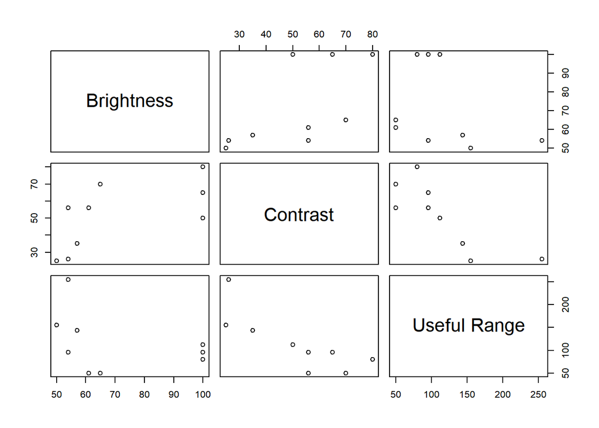

```r
library(readxl)
q2 <- read_excel("~/GitHub/Module-4-Pair-Quiz/question2.xls")
plot(q2)
```

```r
Brightness <- q2$Brightness
Contrast <- q2$Contrast
Useful_Range <-q2$`Useful Range`


multiple_regression <- lm(Useful_Range ~ Brightness + Contrast, data=q2)
summary(multiple_regression)
```

```
##
## Call:
## lm(formula = Useful_Range ~ Brightness + Contrast, data = q2)
##
## Residuals:
##    Min     1Q Median     3Q    Max
## -42.81 -28.52  -1.09   8.63  71.58
##
## Coefficients:
##             Estimate Std. Error t value Pr(>|t|)
## (Intercept) 224.7179    50.1217   4.483  0.00418 **
## Brightness    0.7768     0.8514   0.912  0.39672
## Contrast     -3.2017     0.9667  -3.312  0.01617 *
## ---
## Signif. codes:  0 '***' 0.001 '**' 0.01 '*' 0.05 '.' 0.1 ' ' 1
##
## Residual standard error: 40.97 on 6 degrees of freedom
## Multiple R-squared:  0.6896, Adjusted R-squared:  0.5861
## F-statistic: 6.664 on 2 and 6 DF,  p-value: 0.02992
```

We obtain values such as the Residuals, coefficients, t-values, and residual standard error. We even get the p-value of the whole data set.

From the coefficients above, we can form the multiple linear regression model below

We use:

$$\hat{y} = Intercept + CoeffBrightness(X_1) + CoeffContrast(X_2)$$

$$Useful Range = 224.7179 + (0.7768)(X_1) + (-3.2017)(X_2)$$

## **B.**

2. Estimate $\sigma^2$

We use the formula: $\sigma^2 = \frac{SSE}{n-(k+1)}$, where k is the number of coefficients

SSE here is obtained from the intercept of Error values from the lm table above.

[output not shown]

This estimate is close to the values obtained when using the variance function for the values for Question 2.

## **C.**

3. Compute the standard errors of the regression coefficients.

Taking these values from the lm function above:

$Brightness = 0.8514$

$Contrast = 0.9667$

## **D.**

4. Predict the useful range when brightness = 80 and contrast = 75.

We can use the coefficients for Brightness and Contrast to predict Useful Range. Given: Brightness = 80 Contrast = 75

We plug in Brightness into $X_1$ and Contrast into $X_2$

$$Useful Range = 224.7179 + (0.7768)(80) + (-3.2017)(75)$$

```
## [1] 46.7344
```

Thus, the value of Useful Range when Brightness is 80 and Contrast is 75 is

$$Useful Range = 46.7344$$

## **E.**

5. Test for significance of regression using α=0.05. What is the P-value for this test?

Testing for significance of regression

We can use the p-value of 0.02992 from above.

Then, we can compare this p-value of 0.02992 to alpha = 0.05

$0.02992 < 0.05$

We conclude that the regression is significant and can be observed between the values.

## **F.**

6. Construct a t-test on each regression coefficient. What conclusions can you draw about the variables in this model? Use α=0.05.

We form the hypothesis:

$$H_0: \beta_1 = 0$$
meaning no relationship in the regression model. Amounts to a bad predictor

$$H_1: \beta_1 > 0$$
meaning strong relationship in the regression model. Amounts to a good predictor.

Using the equation:

$$t_1 = \frac{b_1}{se(b_1)}$$

t-value of Brightness
$$t_1 = \frac{0.7768}{0.8514}=0.912$$

Then we find p-value at $\alpha=0.05$ using pnorm

```
## [1] 0.1808844
```

Greater than $\alpha=0.05$

Because the p-value is greater than 0.05, this means that the Brightness variable is not a good predictor of the regression model.

t-value of Contrast
$$t_2 = \frac{-3.2017}{0.9667}=-3.312$$

```
## [1] 0.0004631577
```

Lesser than $\alpha=0.05$

This means that the p-value obtained from this shows that the Contrast variable is a good predictor of the regression model.